# Aside

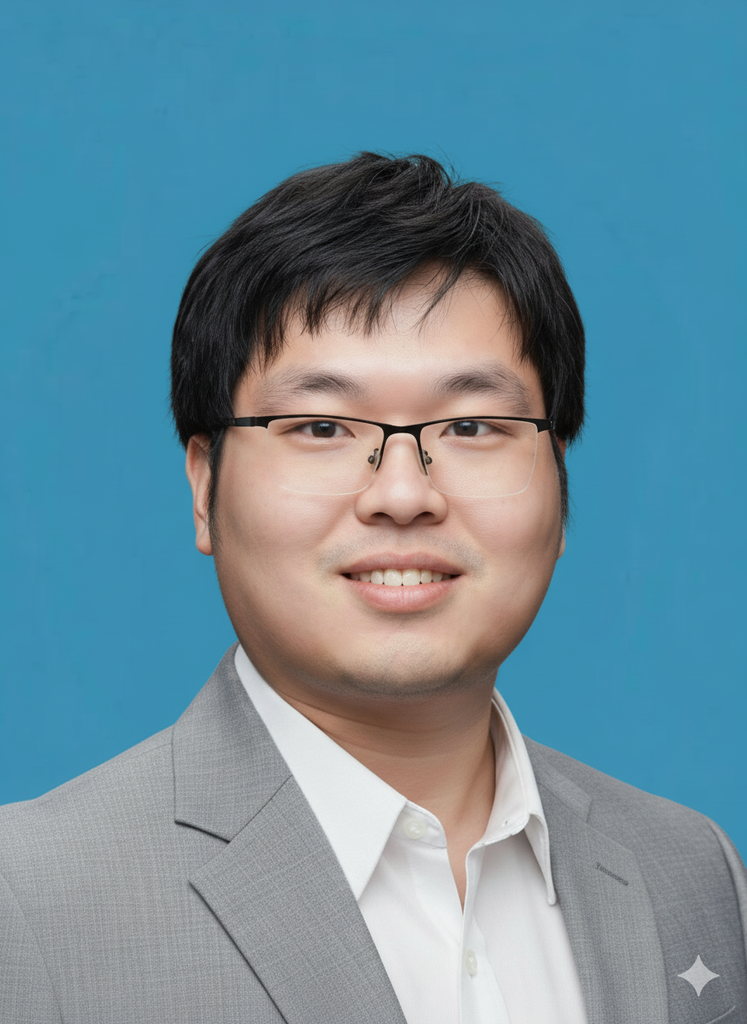

## Contact

- shaoqing.dai@outlook.com
- GISerDaiShaoqing
- Homepage

## Language Skills

R

GIS

3D Modeling

Python

Statistics

RS & Earth Observation

## Disclaimer

Made with the R package [**pagedown**](https://github.com/rstudio/pagedown).

The source code is available [on GISerDaiShaoqing/Curriculum-Vitae-Latex](https://github.com/GISerDaiShaoqing/Curriculum-Vitae-Latex).

Last updated on 2026-09-19.

# Main

## Working Experience

### Key-Funded Postdoctoral Researcher

Geography Postdoctoral Program, School of Resource and Environmental Sciences, Wuhan University

Wuhan, China

Current - 2025.01

- Co-mentor: Prof. Peng Jia

## Education

### Ph.D., Geoinformatics

Faculty of Geo-information Science and Earth Observation (ITC), University of Twente

Enschede, Netherlands

2024.06 - 2020.01

- Thesis: Improving obesogenic environmental assessments with advanced geospatial methods
- Supervised by Prof. Peng Jia, Prof. Alfred Stein

### M.Sc., Ecology

Institute of Urban Environment, Chinese Academy of Sciences, University of Chinese Academy of Sciences

Xiamen, China

2019.06 - 2016.09

- Thesis: Creating a Carbon Source and Sink Map by Coupling an Ecological Process Model with an Emission Inventory to Study a Carbon Balance
- Supervised by Prof. Yin Ren

### B.S., Geographical Science (National Talents Training Base)

School of Geographical Sciences, Fujian Normal University

Fuzhou, China

2016.06 - 2012.09

- Thesis: The Planning Location and Design of Smart Campus Based on BIM and GIS: A Case Study of Fujian Normal University
- Supervised by Prof. Huixian Jiang

## Research Interests

### Health Geography; Urban Visual Intelligence; Spatial Lifecourse Health; Spatial Statistics; GeoAI; Spatial-Temporal Big Data

N/A

N/A

Current - 2012

## Developed Open Software

### Note of Applied Statistics with R

N/A

N/A

Current - 2017

- http://gisersqdai.top/Note-of-Applied-Statistics-with-R-Book/

### D3L Tool of NASA Satellite

N/A

N/A

Current - 2018

### Geographical detector in R

N/A

N/A

Current - 2018

- The geographical detector software based on R

### GitHub Paper Notebook

N/A

N/A

Current - 2018

- The software for notebook of papers

### rgeoda

N/A

N/A

Current - 2019

- rgeoda is an R package for spatial data analysis based on libgeoda and GeoDa (contributor).

### COVID-19 Dashboard shiny app

N/A

N/A

Current - 2020

### Awesome COVID-19

N/A

N/A

Current - 2020

- Resources of COVID-19 research. http://covid19.gisersqdai.top/en-us/

### MetS score calculator shiny app

N/A

N/A

Current - 2023

- A shiny app to calculate MetS score. https://gisersqdai.shinyapps.io/mets_severiity_calculator/

## Awards & Honors

### Best Oral Presentation Award in 3rd Urban Agglomeration Green Development Conference

N/A

N/A

2025

- Urban Agglomeration Green Development Special Committee, Chinese Society for Urban Studies

N/A

N/A

2025

- Beijing Chengyuan Digital Technology Co. Ltd., World Urban Planning Education Network, Beijing Planning Institute Hongdu Planning and Architectural Design Research Institute Co. Ltd.

### Special Program for the Introduction of Overseas Postdoctoral Talents

N/A

N/A

2025

- Ministry of Education of the People’s Republic of China

### Outstanding contributions to COVID-19 epidemic prevention and control

N/A

N/A

2022

- Health commission of Tumot Left Banner, Inner Mongolia Autonomous Region

### The National 2nd Prize in the 5th Planning Decision Support Model Design Contest (Chengyuan Cup)

N/A

N/A

2021

- Beijing Chengyuan Digital Technology Co. Ltd., World Urban Planning Education Network, Beijing Planning Institute Hongdu Planning and Architectural Design Research Institute Co. Ltd., Beijing City Lab, Baidu Map Huiyan, China Unicom Smart Footprint

### China Scholarship Council (CSC)

N/A

N/A

2019

- China Scholarship Council

### The 2nd Grade Scholarship of Yonker Environmental Protection

N/A

N/A

2019

- Yonker Environmental Protection Co. Ltd.

### The 1st Grade Scholarship of Institute of Urban Environment, Chinese Academy of Sciences

N/A

N/A

2019

- Institute of Urban Environment, Chinese Academy of Sciences

### The Scientific and Technological Innovation Award of Outstanding Graduate Students of the Ecological Society of China

N/A

N/A

2019

- Ecological Society of China

### National Scholarship for M.Sctop 2-3%

N/A

N/A

2018

- Ministry of Education of the People’s Republic of China

### The National 3rd Prize in the 2nd Big Data Support Spatial Planning and Design Competition

N/A

N/A

2018

- Urban Big Data Special Committee, Chinese Society for Urban Studies

### “Applied Energy”2018 Summer School Certification

N/A

N/A

2018

- The Applied Energy Innovation Institute, Department of Earth System Science, Tsinghua University, China Emission Accounts & Datasets (CEADs)

### Merit Students in the academic year 2017-2018

N/A

N/A

2018

- University of Chinese Academy of Sciences

### The 2nd Grade Scholarship of Institute of Urban Environment, Chinese Academy of Sciences

N/A

N/A

2018

- Institute of Urban Environment, Chinese Academy of Sciences

### The 1st Scholarship of Institute of Urban Environment, Chinese Academy of Sciences

N/A

N/A

2018

- Institute of Urban Environment, Chinese Academy of Sciences

### The National Winning Award in 2017 “Sharing Cup” College Student Science and Technology Resource Sharing Service Innovation Contest

N/A

N/A

2018

- National Science & Technology Infrastructure Center

### “Excellent Volunteer” award of 15th User Conference of Esri China

N/A

N/A

2017

- Esri China Information Technology Co. Ltd.

### Merit Students in the academic year 2016-2017

N/A

N/A

2017

- University of Chinese Academy of Sciences

### The National Winning Award in 2015 Esri Cup National Collegiate Development Contest in GIS·3D Modeling and Design

N/A

N/A

2015

- Chinese Society of Geodesy Photogrammetry and Cartography, Esri China Information Technology Co. Ltd.

### Innovation Scholarships in the academic year 2014-2015

N/A

N/A

2015

- Fujian Normal University

### The National 3rd Prize in the Smart City Special Event Contest, the 14th Challenge Cup National College Students’ Extracurricular Academic Science and Technology Works Contest

N/A

N/A

2015

- Chinese Communist Youth League, China Association for Science and Technology, Ministry of Education of the People’s Republic of China, All-China Students’ Federation

### Scientific and Technological Innovation award and Nomination, the First Annual Fujian Normal University Student Selection

N/A

N/A

2015

- Fujian Normal University

### The School Wining Award during the 9th Challenge Cup National College Students’ Extracurricular Academic Science and Technology Works Contest

N/A

N/A

2015

- Fujian Normal University

### Innovation Scholarships in the academic year 2013-2014

N/A

N/A

2014

- Fujian Normal University

### The National 3rd Prize in 2014 MathorCup Global Collegiate Mathematical Contest in Modeling

N/A

N/A

2014

- Chinese Society of Optimization, Overall Planning and Economical Mathematics

### “Excellent League Cadres” in the academic year 2013-2014

N/A

N/A

2014

- Fujian Normal University

### “Excellent League Cadres” in the academic year 2013-2014

N/A

N/A

2014

- School of Geographical Sciences, Fujian Normal University

### “Excellent League Cadres” in the academic year 2012-2013

N/A

N/A

2013

- School of Geographical Sciences, Fujian Normal University

## Academic Service & Affiliations

### Editors

npj Digital Public Health

N/A

Current - 2026

- Editorial Board Member

### Editors

Journal of Subtropical Resources and Environment

N/A

Current - 2026

- Youth Editorial Board Member

### Editors

BMC Public Health

N/A

Current - 2025

- Editorial Board Member

### Editors

Frontiers in Public Health, Frontiers in Psychology, Frontiers in Forests and Global Change

N/A

Current - 2025

- Associate Editor

### Editors

Land Special Issue, “Urban Spatial Planning for Health and Well-Being”

N/A

Current - 2025

- Guest Editor

### Affiliations

AI 4D City lab, Hong Kong University of Science and Technology (Guangzhou)

N/A

Current - 2024

- Visiting Scholar

### Affiliations

International Institute of Spatial Lifecourse Health (ISLE)

N/A

Current - 2019

- Fellow

### Affiliations

GeoDa Center, rgeoda, libgeoda Github Organizations

N/A

Current - 2019

- Contributor

### Social Media Volunteer

The Organization “Sustainable Cities & Mobility”

N/A

Current - 2015

- Volunteer

### Science & Technology Service

Pang Changle Expert Grassroots Scientific Research Workstation, Mengzi Shuchan Investment and Development Co. Ltd

N/A

Current - 2025

- Chief Researcher (PI)

### Conference & Society Service

The Geographical Society of China

N/A

Current - 2025

- Member

### Conference & Society Service

International Society for Photogrammetry and Remote Sensing Student Consortium

N/A

Current - 2024

- Member

### Workshop Lecturer

UrbanParty

N/A

Current - 2024

- Lecturer

### Peer-Reviewed Journal & Conference Reviewer

**Health & epidemiology**: European Heart Journal, BMC Public Health, Frontiers in Public Health, HealthCare, Children, Artificial Intelligence in Emergency Medicine, Biology and Life Sciences Forum; **GIS & remote sensing**: GIScience & Remote Sensing, International Journal of Geographical Information Science, International Journal of Digital Earth, Spatial Statistics, Information Geography, ISPRS Conference, CPGIS Conference; **environment & ecology**: Ecological Indicators, Environmental Research, Methods in Ecology and Evolution, City and Environment Interactions, Environmental Modelling & Software, Frontiers in Environmental Science, Frontiers in Forests and Global Change, Forest Ecology & Management, Regional Environmental Change, Environmental Modeling & Assessment, Frontiers in Earth Science; **urban & built environment**: Sustainable Cities and Society, Habitat International, Cities, Frontiers of Architectural Research, Journal of Asian Architecture and Building Engineering, Urban & Building Science, Shanghai Urban Planning Review; **energy, resources & carbon**: Applied Energy, Resources, Conservation and Recycling, Carbon Balance and Management, Carbon Management; **data, computing & open science**: Information Processing & Management, Scientific Data, Sensors, Data in Brief, The Journal of Open Source Software, Transactions in Urban Data, Science, and Technology; **multidisciplinary & others**: Scientific Reports, Sustainability, Applied Economics Letters, Heliyon, Discover Global Society

N/A

Current - 2019

- Reviewer

### Editors

Frontiers in Remote Sensing Special Issue, “Machine Learning for Advanced Remote Sensing: From Theory to Applications and Societal Impact”

N/A

2026 - 2025

- Guest Editor

### Workshop Lecturer

6th International Symposium on Spatial Lifecourse Health Workshop

N/A

2026

- Lecturer

### Science & Technology Service

The 138th Postdoctoral Science and Technology Service Corps, China Postdoctoral Science Foundation

N/A

2025

- Fellow

### Conference & Society Service

2nd National Conference of Information Geography, “Human behaviors, health geography and spatial modeling” session

N/A

2025

- Convener

### Conference & Society Service

5th International Symposium on Spatial Lifecourse Health, “Street view images, human mobility and environmental health” session

N/A

2025

- Convener

### Workshop Lecturer

5th International Symposium on Spatial Lifecourse Health Workshop

N/A

2025

- Lecturer

### Conference & Society Service

2nd World Congress of Geography, “Research on Global Health Wellbeing and Health Geography” session

N/A

2024

- Convener

### Conference & Society Service

4th International Symposium on Spatial Lifecourse Health, “Application of System Simulation Models in Health Domain” session

N/A

2024

- Convener

### Workshop Lecturer

4th International Symposium on Spatial Lifecourse Health Workshop

N/A

2024

- Lecturer

### Workshop Lecturer

Heywhale Community and GISphere, ‘Python x GIS’ GeoAI Workshop

N/A

2024

- Lecturer

### Workshop Lecturer

Training course on ‘Spatial Epidemiology Analysis Methods and Applications’

N/A

2024

- Lecturer

### Social Media Volunteer

GISphere

N/A

2023 - 2020

- Editorial Board, Council Member, Editor in chief of Wechat

### Science & Technology Service

Aliyunqi Community

N/A

2020 - 2018

- Expert

### Conference & Society Service

International Association of Landscape Ecology of China (IALE-China)

N/A

2019 - 2017

- Member

### Editors

The Geographical Tribune of Youth

N/A

2017 - 2013

- Founder, Editor in Chief, Associate Editor, Assistant Editor in Chief

### Social Media Volunteer

Green Bike-Transit

N/A

2017 - 2016

- Volunteer

## Publications-Peer-Reviewed Journal Articles

### Evaluating the Marginal Contribution of Remote Sensing for Forest Biomass Estimation When Inventory Data Exists

Forests

N/A

2026

- Xiaoman Zheng, Ying Su, Yunxia Wang, **Shaoqing Dai**, Yufeng Chi, Guanjun Lin, Yin Ren*
- 17(9): 1094. doi:10.3390/f17091094.
- SCI, IF=3.1

### Toward precision urban resilience: Integrating multimodal large language models with spatial analytics for fire risk governance

Cities

N/A

2026

- Dong Xie, Senhong Cai, Ke Wang, Ce Hou, **Shaoqing Dai**, Jingnan Huang*
- 179: 107449. doi:10.1016/j.cities.2026.107449.
- SSCI, IF=7.0

### High-resolution mapping of demographic compositions based on remote sensing and social media data: a multimodal, multi-output modeling approach

International Journal of Geographical Information Science

N/A

2026

- Ge Qiu, Yuchen Li, **Shaoqing Dai**, Kun Qin, Zhanpeng Wang, Yaolin Liu, Jiping Liu*, Peng Jia*
- online first: 1-35. doi:10.1080/13658816.2026.2702485.
- SCI/SSCI, IF=5.9

### Editorial: Machine learning for advanced remote sensing: from theory to applications and societal impact

Frontiers in Remote Sensing

N/A

2026

- Rui Li*, **Shaoqing Dai**, Bin Jiang, Cong Zhang, Haoyang Yang, Wufan Zhao
- 7: 1931394. doi:10.3389/frsen.2026.1931394.
- ESCI, IF=3.5

### Measuring causal strengths from spatial cross-sectional data with geographical cross mapping cardinality

International Journal of Geographical Information Science

N/A

2026

- Wenbo Lyu, **Shaoqing Dai**, Yongze Song*, Wufan Zhao, Wen Yi, Yumiao Xiao, Nan Jia
- online first: 1-23. doi:10.1080/13658816.2026.2687121.
- SCI/SSCI, IF=5.9

### Understanding multi-perspective urban green space patterns under urban expansion: Evidence from Guangzhou

Sustainable Cities and Society

N/A

2026

- Qiming Liu, **Shaoqing Dai**, Guosheng Yang, Cai Wu*
- 147: 107534. doi:10.1016/j.scs.2026.107534.
- SCI, IF=13.3

### Bridging street view coverage disparities through geographic identity preserving generation from satellite view

ISPRS Journal of Photogrammetry and Remote Sensing

N/A

2026

- Zongrong Li, Fan Zhang, **Shaoqing Dai***, Wufan Zhao*
- 236: 622-639. doi:10.1016/j.isprsjprs.2026.03.049.
- SCI, IF=12.9

### Causal discovery in urban data with temporal empirical dynamic modeling: The R package tEDM

Computers, Environment and Urban Systems

N/A

2026

- Wenbo Lyu, Yangyang Lei, Wen Yi, Yongze Song, Xiao Li, **Shaoqing Dai**, Yiming Qin, Wufan Zhao
- 127: 102435. doi:10.1016/j.compenvurbsys.2026.102435.
- SSCI, IF=8.9

### Effects of short-term exposure to air pollutants on real-time blood pressure: a wearable device-based study in China

Journal of Urban Health

N/A

2025

- Chen Li, Xiu Yang, Kun Qin, Shuhan Yang, **Shaoqing Dai**, Chun Yin, Shujuan Yang, Yuanyuan Shi, Peng Jia
- 102(5): 1011-1023. doi:10.1007/s11524-025-01017-3.
- SCI, IF=3.2

### Assessing variations in river networks under urbanization across metropolitan plains using a multi-metric approach

Land

N/A

2025

- Zhixin Lin, Shuang Luo, Miao Lu, **Shaoqing Dai**, Youpeng Xu
- 14(10): 1994. doi:10.3390/land14101994.
- SSCI, IF=3.5

### Agricultural socialized service system and its mechanism driving industrial upgrade: based on an empirical study on value chain theory

Resources & Industries

N/A

2025

- Yuxei Lin, Feng Lu, Zhengyi Xu, Junfeng Xue, **Shaoqing Dai**, Xinying Zhang
- 7(05): 139-150. doi:10.13776/j.cnki.resourcesindustries.20250901.006.
- in Chinese

### High-resolution population density mapping in urban areas using a contextualized geographically weighted neural network (CGWNN) model

Applied Geography

N/A

2025

- Ge Qiu, Yuchen Li, Kun Qin, Chen Li, Shuhan Yang, Chun Yin, Yaolin Liu*, **Shaoqing Dai***, Peng Jia*
- 182: 103708. doi:10.1016/j.apgeog.2025.103708.
- SSCI, IF=7.4

### Identifying landscape patterns at different scales asdriving factors for urban flooding

Ecological Indicators

N/A

2025

- Yao Li, Frank Badu Osei, **Shaoqing Dai**, Tangao Hu, Alfred Stein.
- 176: 113614. doi:10.1016/j.ecolind.2025.113614.
- SCI, IF=8.7

### Built environments and obesity: A framework considering residences, commute routes, and workplaces

Cities

N/A

2025

- Chun Yin, Zhe Zhang, **Shaoqing Dai**, Yiyi Chen
- 160: 105842. doi:10.1016/j.cities.2025.105842.
- SSCI, IF=7.0

### Toward 3D hedonic price model for vertically developed cities using street view images and machine learning methods

Habitat International

N/A

2025

- Yue Ying, **Shaoqing Dai***, Mila Koeva, Monika Kuffer, Claudio Persello, Wen Zhou, Jaap Zevenbergen
- 156: 103288. doi:10.1016/j.habitatint.2025.103288.
- SSCI, IF=8.5

### Heterogeneous impacts of and vulnerabilities to the COVID-19 pandemic

Landscape Ecology

N/A

2025

- Manyao Li#, **Shaoqing Dai#**, Yuanyuan Shi#, Kun Qin#, Ross Brownson, Yan Kestens, Miyang Luo, Shiyong Liu, Jing Su, Gordon G. Liu, Shujuan Yang, Peng Jia
- 40: 32. doi:10.1007/s10980-024-02039-z
- SCI, IF=4.7

### Long-term exposure to PM2.5 chemical constituents and diabesity: evidence from a multi-center cohort study in China

The Lancet Regional Health–Western Pacific

N/A

2024

- Changwei Cai, Shuzhen Zhu, Mingfang Qin, Xiaoqing Li, Chuanteng Feng, Bin Yu, **Shaoqing Dai**, Ge Qiu, Yuchen Li, Tingting Ye, Wenling Zhong, Ying Shao, Lan Zhang, Peng Jia, Shujuan Yang
- 47: 101100. doi:10.1016/j.lanwpc.2024.101100
- SCI/SSCI, IF=9.4

### Street view imagery-based built environment auditing tools: a systematic review

International Journal of Geographical Information Science

N/A

2024

- **Shaoqing Dai**, Yuchen Li, Alfred Stein, Shujuan Yang, Peng Jia.
- 38(6): 1136-1157. doi:10.1080/13658816.2024.2336034
- SCI/SSCI, IF=5.9

### Spatiotemporal patterns of air pollutants over the epidemic course: a national study in China

Remote Sensing

N/A

2024

- Kun Qin#, Zhanpeng Wang#, **Shaoqing Dai#**, Yuchen Li, Manyao Li, Chen Li, Ge Qiu, Yuanyuan Shi, Chun Yin, Shujuan Yang, Peng Jia*
- 16(7): 1298. doi:10.3390/rs16071298.
- SCI, IF=4.3

### State of the art of lifecourse cohort establishment

China CDC Weekly

N/A

2024

- **Shaoqing Dai**, Ge Qiu, Yuchen Li, Shuhan Yang, Shujuan Yang, Peng Jia
- 6(14), 300–304. doi:10.46234/ccdcw2024.058.
- SCI/SSCI, IF = 3.5

### Long-term dynamic monitoring and driving force analysis of eco-environmental quality in China

Remote Sensing

N/A

2024

- Weiwei Zhang, Zixi Liu, Kun Qin, **Shaoqing Dai**, Huiyuan Lu, Miao Lu, Jianwan Ji, Zhaohui Yang, Chao Chen, Peng Jia
- 16(6): 1028 doi:10.3390/rs16061028.
- SCI, IF=4.3

### Mixed land use has opposite associations with subjective well-being through social capital: Spatial heterogeneity in residential and workplace neighborhoods

Travel Behaviour and Society

N/A

2024

- Chun Yin, Jiahang Liu, **Shaoqing Dai**, Bindong Sun
- 35, 100724. doi:10.1016/j.tbs.2023.100724.
- SSCI, IF=5.8

### Local carbon emission zone construction in the highly urbanized regions: Application of residential and transport CO<sub>2</sub> emissions in Shanghai, China

Building and Environment

N/A

2024

- Yunfeng Tian, Shudi Zuo, Jiaheng Ju, **Shaoqing Dai**, Yin Ren, Panfeng Dou.
- 247, 111007. doi:10.1016/j.buildenv.2023.111007.
- SCI, IF=8.4

### Assessing Spatiotemporal Bikeability Using Multi-Source Geospatial Big Data: A Case Study of Xiamen, China

International Journal of Applied Earth Observation and Geoinformation

N/A

2023

- **Shaoqing Dai**, Wufan Zhao, Yanwen Wang, Xiao Huang, Zhidong Chen, Jinghan Lei, Alfred Stein, Peng Jia.
- 125, 103539. doi:10.1016/j.jag.2023.103539.
- SCI, IF=8.2

### Development and validation of an age-sex-ethnicity-specific metabolic syndrome score in the Chinese adults

Nature Communications

N/A

2023

- Shujuan Yang, Bin Yu, Wanqi Yu, **Shaoqing Dai**, Chuanteng Feng, Ying Shao, Xing Zhao, Xiaoqing Li, Tianjing He, Peng Jia.
- 14(1), 6988. doi:10.1038/s41467-023-42423-y
- SCI, IF=18.1

### Environmental determinants of childhood obesity: a meta-analysis

The Lancet Global Health

N/A

2023

- Peng Jia, Yuanyuan Shi, Qi Jiang, **Shaoqing Dai**,Bin Yu, Shuhan Yang, Ge Qiu, Shujuan Yang.
- 11, S7. doi:10.1016/S2214-109X(23)00092-X.
- SCI/SSCI, IF=22.5

### The importance of the functional mixed entropy for the explanation of residential and transport CO<sub>2</sub> emissions in the urban center of China

journal of Cleaner Production

N/A

2022

- Shudi Zuo, **Shaoqing Dai**, Jiaheng Ju, Fanxin Meng, Yin Ren, Yunfeng Tian, Kaide Wang
- 380, 134947. doi:10.1016/j.jclepro.2022.134947.
- SCI, IF=10.7

### Global spreading of Omicron variant of COVID-19

Geospatial Health

N/A

2022

- Pengxin Zhang, Shuhan Yang, **Shaoqing Dai**, Darren How Jin Aik, Shujuan Yang, Peng Jia.
- Geospatial Health. 17. doi:10.4081/gh.2022.1083.
- SCI, IF=1.5

### Quantifying urban mass gain and loss by a GIS‐based material stocks and flows analysis. Journal of Industrial Ecology

Journal of Industrial Ecology

N/A

2022

- Yupeng Liu, Jiajia Li, Weiqiang Chen, Lulu Song, **Shaoqing Dai**.
- 26(3), 1051-1060. doi:10.1111/jiec.13252.
- SCI, IF=5.7

### Identification of two-dimensional copper signatures in human blood for bladder cancer with machine learning

Chemical Science

N/A

2022

- Weichao Wang, Xian Liu, Changwen Zhang, Fei Sheng, Shanjun Song, Penghui Li, **Shaoqing Dai**, Bin Wang, Dawei Lu, Luyao Zhang, Xuezhi Yang, Zhihong Zhang, Sijin Liu, Aiqian Zhang, Qian Liu, Guibin Jiang.
- 3(6), 1648-1656. doi:10.1039/D1SC06156A.
- SCI, IF=8.1

### Improving plot-level model of forest biomass: A combined approach using machine learning with spatial statistics

Forests

N/A

2021

- **Shaoqing Dai**, Xiaoman Zheng, Lei Gao, Chengdong Xu, Shudi Zuo, Qi Chen, Xiaohua Wei, Yin Ren
- 12(12), 1663. doi:10.3390/f12121663.
- SCI, IF=3.1

### New approaches to anticipate the risk of reverse zoonosis

Trends in Ecology & Evolution

N/A

2021

- Peng Jia, **Shaoqing Dai**, Tong Wu, Shujuan Yang.
- 36(7), 580-590. doi:10.1016/j.tree.2021.03.012.
- SCI, IF=17.9

### Refined water security assessment for sustainable water management: A case study of 15 key cities in the Yangtze River Delta, China

Journal of Environmental Management

N/A

2021

- Panfeng Dou, Shudi Zuo, Yin Ren, Manuel J. Rodriguez, **Shaoqing Dai**.
- 290, 112588. doi:10.1016/j.jenvman.2021.112588.
- SCI, IF=9.2

### Pitfalls in Modeling Asymptomatic COVID-19 Infection

Frontiers in Public Health

N/A

2021

- Shujuan Yang, **Shaoqing Dai**, Yulin Huang, Peng Jia.
- 9, 593176. doi:10.3389/fpubh.2021.593176.
- SCI/SSCI, IF=4.1

### High spatial resolution mapping of steel resources accumulated above ground in mainland China: Past trends and future prospects

Journal of Cleaner Production

N/A

2021

### The direct and interactive impacts of hydrological factors on bacillary dysentery across different geographical regions in central China.

Science of the Total Environment

N/A

2020

- Shudi Zuo, Lianping Yang, Panfeng Dou, Hung Chak Ho, **SQ. Dai**, Wenjun Ma, Yin Ren, Cunrui Huang.
- 764, 144609. doi:10.1016/j.scitotenv.2020.144609.
- SCI, IF=8.0

### Investigating the uncertainties propagation analysis of CO<sub>2</sub> emissions gridded maps at the urban scales: a case study of Jinjiang city, China.

Remote Sensing

N/A

2020

- **Shaoqing Dai**, Yin Ren, Shudi Zuo, Chengyi Lai, Jiajia Li, Shengyu Xie, Bingchu Chen.
- 12(23), 3932. doi:10.3390/rs12233932
- SCI, IF=4.3

### The Evaluation of Health Effect of Short-term Exposure to PM2.5 during Spring Festival: A Case Study of 25 Cities in the Yangtze River Delta

Shanghai Urban Planning Review

N/A

2020

- **Shaoqing Dai**, Jiajia Li, Weixu Yang, Fangyu Chen, Huixian Jiang.
- 05, 22-29. doi:10.11982/j.supr.20200504.
- in Chinese

### Natural environment and childhood obesity: A systematic review

Obesity Reviews

N/A

2020

- Peng Jia, **Shaoqing Dai**, Kristen. E. Rohli, Robert V. Rohli, Yanan Ma, Chao Yu, Xiongfeng Pan, Weiqi Zhou.
- 1-9. doi:10.1111/obr.13097
- SCI, IF=7.6

### Response of syntrophic bacterial and methanogenic archaeal communities in paddy soil to soil type and phenological period of rice growth

Journal of Cleaner Production

N/A

2020

- XiaoFang Pan, Hu Li, Lixin Zhao, Xiaoru Yang, Jianqiang Su, **Shaoqing Dai**, Jing Ning, Chunxing Li, Guanjing Cai, GeFu Zhu.
- 278, 123418. doi:10.1016/j.jclepro.2020.123418
- SCI, IF=10.7

### Green space access in the neighbourhood and childhood obesity

Obesity Reviews

N/A

2020

- Peng Jia, Xinxi Cao, Hongxi Yang, **Shaoqing Dai**, Pan He, Ganlin Huang, Tong Wu, Yaogang Wang.
- 1-12. doi:10.1111/obr.13100
- SCI, IF=7.6

### Neighbourhood speed limit and childhood obesity

Obesity Reviews

N/A

2020

- Miyang Luo, Hanqi Li, Xiongfeng Pan, Teng Fei, **Shaoqing Dai**, Ge Qiu, Yuxuan Zou, Heleen Vos, Jiayou Luo, Peng Jia.
- 1-11. doi:10.1111/obr.13052
- SCI, IF=7.6

### Treatment of high-ash industrial sludge for producing improved char with low heavy metal toxicity

Journal of Analytical and Applied Pyrolysis

N/A

2020

- Shengyu Xie, Guangwei Yu, Chunxing Li, Jie Li, Gang Wang, **Shaoqing Dai**, Yin Wang.
- 150, 104866. doi:10.1016/j.jaap.2020.104866
- SCI, IF=6.7

### Access to bike lanes and childhood obesity: A systematic review and meta‐analysis

Obesity Reviews

N/A

2020

- Xiongfeng Pan, Li Zhao, Jiayou Luo, Yinhao Li, Lin Zhang, Tong Wu, Melody Smith, **Shaoqing Dai**, Peng Jia.
- 1-11. doi:10.1111/obr.13042
- SCI, IF=7.6

### A spatial database of CO<sub>2</sub> emissions, urban form fragmentation and city-scale effect related impact factors for the low carbon urban system in Jinjiang city, China

Data in Brief

N/A

2020

- **Shaoqing Dai**, Shudi Zuo, Yin Ren.
- 29, 105274. doi:10.1016/j.dib.2020.105274
- ESCI, IF=1.9

### More fragmentized urban form more CO<sub>2</sub> emissions? A comprehensive relationship from the combination analysis across different scales

Journal of Cleaner Production

N/A

2020

- Shudi Zuo, **Shaoqing Dai**, Yin Ren.
- 244, 118659. doi:10.1016/j.jclepro.2019.118659
- SCI, IF=10.7

### The impacts of climate and land use/land cover changes on water yield service in Ningbo region

Acta Scientiae Circumstantiae

N/A

2019

- Panfeng Dou, Shudi Zuo, Yin Ren, **Shaoqing Dai**, Guoliang Yun
- 39(7), 2398-2409. doi:10.13671/j.hjkxxb.2019.0122
- CSCD, in Chinese

### A GIS-based high spatial resolution assessment of large-scale PV power generation potential and associated CO<sub>2</sub> emission reduction in China

Applied Energy

N/A

2019

- Qing Yang, Tianyue Huang, Saige Wang, Jiashuo Li, **Shaoqing Dai**, Sebastian Wright, Yuxuan Wang, Huaiwu Peng.
- 247, 254-269. doi:10.1016/j.apenergy.2019.04.005
- SCI, IF=12.2

### PM2.5 spatiotemporal evolution and drivers in the Yangtze River Delta between 2005 and 2015

Atmosphere

N/A

2019

- Guoliang Yun, Yuanrong He, Yuantong Jiang, Panfeng Dou, **Shaoqing Dai**.
- 10(2), 55. doi:10.3390/atmos10020055
- SCI, IF=2.6

### Determining the Mechanisms that Influence the Surface Temperature of Urban Forest Canopies by Combining Remote Sensing Methods, Ground Observations, and Spatial Statistical Models

Remote Sensing

N/A

2018

- Shudi Zuo, **Shaoqing Dai**, Xiaodong Song, Chengdong Xu, Yilan Liao, Weiyin Chang, Qi Chen, Yaying Li, Jianfeng Tang, Wang Man, Yin Ren.
- 10(11), 1814. doi:10.3390/rs10111814
- SCI, IF=4.3

### Analysis of Heavy Metal Sources in the Soil of Riverbanks Across an Urbanization Gradient

International Journal of Environmental Research and Public Health

N/A

2018

- Shudi Zuo, **Shaoqing Dai**, Yaying Li, Jianfeng Tang, Yin Ren.
- 15(10), 2175. doi:10.3390/ijerph15102175
- SCI, IF=4.6

### Influence of walking environment on robbery, snatch and theft crime in urban area, H city, China

Scientia Geographica Sinica

N/A

2018

- **Shaoqing Dai**, Huixian Jiang, Jiajia Li, Xian Su, Juan Wu, Yin Ren.
- 38(8), 1235-1244. doi:10.13249/j.cnki.sgs.2018.08.005
- CSCD, in Chinese

### High-resolution mapping of direct CO<sub>2</sub> emissions and uncertainties at the urban scale

Proceedings of Spatial Accuracy 2018.

N/A

2018

- **Shaoqing Dai**, Shudi Zuo, Yin Ren.
- 88-90.
- EI

### Improving the prediction accuracy of forest aboveground biomass benchmark map by integrating machine learning and spatial statistics

Proceedings of Spatial Accuracy 2018.

N/A

2018

- **SQ. Dai**, Xiaoman Zheng, Shudi Zuo, Yin Ren.
- 80-83
- EI

### Individual and Interactive Influences of Anthropogenic and Ecological Factors on Forest PM2.5 Concentrations at an Urban Scale

Remote Sensing

N/A

2018

- Guoliang Yun, Shudi Zuo, **Shaoqing Dai**, Xiaodong. Song, Chengdong Xu, Yilan Liao, Peiqiang Zhao, Weiyin Chang, Qi Chen, Yaying Li, Jianfeng Tang, Wang Man, Yin Ren.
- 10(4), 521. doi:10.3390/rs10040521
- SCI, IF=4.3

### Research on the effects of different policy tools on China’s emissions reduction innovation

China Population, Resources and Environment

N/A

2018

- Qin Ye, Gang Zeng, **Shaoqing Dai**, Fenglong Wang.
- 28(02), 115-122. doi:10.12062/cpre.20170915
- CSCD, in Chinese

### Research on the effects of command-and-control and market-oriented policy tools on China’s energy conservation and emissions reduction innovation

Chinese Journal of Population Resources and Environment

N/A

2017

- Qin Ye, **Shaoqing Dai**, Gang Zeng.
- 16(1), 1-11. doi:10.1080/10042857.2017.1418273.
- ESCI, IF=4.7

### Landscape-Scale Simulation Analysis of Waterlogging and Sponge City Planning for a Central Urban Area in Fuzhou City, China.

International Low Impact Development Conference China 2016: LID Applications in Sponge City Projects.

N/A

2017

- **Shaoqing Dai**, Jiajia Li, Shudi Zuo, Yin Ren, Huixian Jiang.
- 251-260. doi:10.1061/9780784481042.028
- EI

### The Analysis of Urban Spatial Development Pattern in Beijing Based on the Big Data of Government

Geomatics World

N/A

2016

- Miaoyi Li, **Shaoqing Dai**, Jingyuan Wang, Zhenjiang Shen.
- 23(3), 20-26. doi:10.3969/j.issn.1672-1586.2016.03.004
- JST

## Publications-Book Chapter

### The evaluation of health effect of short-term exposure to PM2.5 during Spring Festival: a case study of 25 cities in the Yangtze River Delta

In Applications of Medical Big Data and Artificial Intelligence (in Chinese) edited by Xifeng Wu, Guihua Zhuang, Yan Jin, Chaolong Wang, Chen Mao, Beijing: People’s Medical Publishing House. ISBN:9787117387644.

N/A

2026

- **Shaoqing Dai**, Huixian Jiang

### Healthcare service allocation and planning & Emerging fields in health geography

In Health Geography (in Chinese) edited by Peng Jia, Beijing: China Higher Education Press. ISBN:978-7-04-063403-7

N/A

2025

- Yuanyuan Shi, **Shaoqing Dai**, Peng Jia

### Assessing bicycle-sharing riding friendliness by fusing multi-source heterogeneous spatio-temporal big data

Planning Decision Support Model Design Compilation 2021 (in Chinese) edit by Beijing Municipal Institute of City Planning and Design, Beijing Chengyuan Digital Technology Co. Ltd., World Urban Planning Education Network, Beijing Planning Institute Hongdu Planning and Architectural Design Research Institute Co. Ltd., Beijing: China Architecture & Building Press. ISBN: 9787112270439

N/A

2022

- **Shaoqing Dai**, Zhidong Chen, Jinghan Lei, Yanwen Wang

### Individual and Interactive Influences of Anthropogenic and Ecological Factors on Forest PM2.5 Concentrations at an Urban Scale

Advances in Quantitative Remote Sensing in China–In Memory of Prof. Xiaowen Li, edited by Shunlin Liang, Guangjian Yan, Jiancheng Shi, Remote Sensing, MDPI, 2019, 316-332. ISBN: 978-3-03897-276-1. https://doi.org/10.3390/books978-3-03897-277-8.

N/A

2019

- Guoliang Yun, Shudi Zuo, **Shaoqing Dai**, Xiaodong. Song, Chengdong Xu, Yilan Liao, Peiqiang Zhao, Weiyin Chang, Qi Chen, Yaying Li, Jianfeng Tang, Wang Man, Yin Ren.

## Publications-Patent

### Improving the accuracy of forest biomass estimate using source analysis and machine learning

CN111814397A

N/A

2020

- Yin Ren, Xiaoman Zheng, **Shaoqing Dai**, Qi Chen, Shudi Zuo

### A biomass estimation method by fusing plot data and forest inventory data

CN110162872A

N/A

2019

- Yin Ren, **Shaoqing Dai**, Shudi Zuo, Xiaoman Zheng.

### A prediction method of subtropical forest biomass

CN108959705A

N/A

2018

- Qi Chen, Yin Ren, Xiaoman Zheng, Shudi Zuo, **Shaoqing Dai**

## Publications-Scientific and Technological Achievements

### ‘Environment + dual carbon goals’ digital and intelligent platform development (Roadshow Signing Project).

Strait (Jinjiang) Technology Innovation Center Co., Ltd., 3rd National Postdoctoral Innovation and Entrepreneurship Competition.

N/A

2025

- **Shaoqing Dai**, Wufan Zhao, Xinying Zhang, Zhixin Lin, Yuanyuan Shi

### Scaling up of carbon sequestration for Eucalyptus plantations based on ETKF-3DVAR hybrid data assimilation

Institute of Urban Environment, Chinese Academy of Sciences and Xiamen University of Technology, 90000890-2349, Xiamen Municipal Bureau of Science and Technology

N/A

2023

- Yin Ren, Shudi Zuo, Lizhong Hua, **Shaoqing Dai**

## Publications-Software Copyright

### ISLE wearable device healthy data management platform. V 1.0

N/A

N/A

2025

- RN: 2025SR1194658

### A water safety monitoring system based on environmental IOT data and InVEST model. V1.0

N/A

N/A

2019

- RN: 2019SR0517519

### A water conservation service monitoring system based on environmental IOT data

N/A

N/A

2018

- RN: 2018SR745897

## Publications-Open Dataset & Code

### Code and data to support ‘Street view imagery for built environment auditing: a systematic review’ (Version 5)

Zenodo.

N/A

2024

- **Shaoqing Dai**, Alfred Stein, Yuchen Li, Shujuan Yang, Peng Jia.
- doi:10.5281/zenodo.10724305

### GISerDaiShaoqing/3dmodelFJNU 1.0 (Version 1.0)

Zenodo.

N/A

2020

- **Shaoqing Dai**
- doi:10.5281/zenodo.4277977

### GISerDaiShaoqing/Urban-Carbon-Dioxide-sources-gridded-maps-and-itsdetemination-in-Jinjiang-city 0.6 (Version 0.6)

Zenodo.

N/A

2020

- **Shaoqing Dai**, Shudi Zuo, Yin Ren.
- doi:10.5281/zenodo.3566072

## Research Projects

### Research on key technologies for low-altitude UAV river-lake inspection and environmental dynamic perception and modeling

Open Funding for Anhui Province Key Laboratory of Physical GeographicEnvironment (2025PGE006)

N/A

2028 - 2026

- **PI**

### Research on urban pollen concentration mapping driven by the synergy of GeoAI and physical models

Open Fund of State Key Laboratory of Resources and Environmental Information System (2025)

N/A

2027 - 2026

- **PI**

### The precise monitoring and analysis for residential environment risk factors and health effects among vulnerable populations

Special Program for the Introduction of Overseas Postdoctoral Talents

N/A

2027 - 2025

- **PI**

### Early Identification and Screening of Risk Factors for Chronic Complications in Diabetes Patients by Combining Traditional Chinese and Western Medicine

Research Project of Collaborative Chronic Disease Management by Traditional Chinese and Western Medicine

N/A

2026 - 2024

- **Investigator**

### Evaluation and prevention of health risks in the community home environment for the elderly and children, and development of appropriate products

National Key Research and Development Plan (2023YFC3604704)

N/A

2026 - 2023

- **Investigator**

### The mechanism of the impact of urban neighborhood-level walkability on child obesity

National Natural Science Foundation of China (42271433)

N/A

2025 - 2022

- **Investigator**

### Investigating the Changes of Residents’ Daily Behaviors, Lifestyles, and Built Environment During the COVID-19 Pandemic

WeSpace Academic Support Plan in 2020: “Tsinghua-Tencent” Emerging Technologies Future Urban Space project

N/A

2021 - 2020

- **PI**

### Research on the key technology research and integration demonstration of urban agglomeration ecological security in the Yangtze River Delta

National Key Research and Development Plan (2016YFC0502704)

N/A

2020 - 2016

- **Investigator**

### The construction of Typhoon Disaster Assessment Index Based on GIS and Multi-source Remote Sensing Data in Fujian Province

Open Fund of the Big Data Institute of Digital Natural Disaster Monitoring in Fujian (NDMBD2018001)

N/A

2019 - 2018

- **Investigator**

### Scaling up of carbon sequestration for Eucalyptus plantations based on ETKF-3DVAR hybrid data assimilation

National Natural Science Foundation of China (31470578)

N/A

2018 - 2015

- **Investigator**

### The Optimization Model of High Education Staff’s Refuge Space Under Earthquake Disaster

The Technological Innovation Plan of University Students, Fujian Normal University (cxxl-2014137)

N/A

2015 - 2014

- **PI**

## Presentations

### Sensing healthy city: from multimodal geographic data and GeoAI to causal inference

6th International Symposium on Spatial Lifecourse Health & 11th International Symposium on Remote Sensing Diagnosis of Environmental Health, Healthy city sensing and planning session

Wuhan, China

2026

### Sensing healthy city: from multimodal geographic data and GeoAI to causal inference

The 10th Symposium on the Application of Geographic Information and Spatial Analysis Technologies in Public Health

Shanghai, China

2026

### Sensing urban obesogenic environments based on multimodal data and GeoAI

2026 Remote Sensing Young Scientists Forum, Smart city and remote sensing large models session

Fuzhou, China

2026

### Sensing healthy city based on multimodal data and GeoAI

Aerospace Symposium on Data Technology and Data Curation, DTDC 2025

Qingdao, China

2025

### Toward health geography: from the COVID-19 pandemic to Health China

GISChat

Online

2025

### Sensing healthy city based on multimodal data and GeoAI

3rd Urban Agglomeration Green Development Conference

Xiamen, China

2025

### Sensing healthy city based on street view imagery and GeoAI

2nd National Conference of Information Geography

Chengdu, China

2025

### Application of night light remote sensing data in urban studies

Urban Party

Online

2025

### Sensing healthy city based on street view imagery and GeoAI

5th International Symposium on Spatial Lifecourse Health

Wuhan, China

2025

### Sensing healthy city based on street view imagery and GeoAI

Annual conference of The Geographical Society of Fujian

Fuzhou, China

2025

### Sensing healthy city based on street view imagery and GeoAI

3rd China Symposium on Urban Sustainable Development

Wuhan, China

2025

### The impact assessment of urban built environment on carbon-air-health nexus: a lifecourse perspective (invited))

3rd China Symposium on Urban Sustainable Development

Wuhan, China

2025

### Development of the frequently used built environmental auditing and simulation tools in health domain

4th International Symposium on Spatial Lifecourse Health

Wuhan, China

2024

### Development of the frequently used environmental exposome observation tools in health domain

2024 Health Geography Youth Scholars Forum

Zhuhai, China

2024

### Bridging environment and human health: from earth observation to human-centered observation (invited))

AI 4D City lab, Hong Kong University of Science and Technology (Guangzhou)

Guangzhou, China

2024

### Assessment of physical activity opportunities based on multi-source geospatial data

9th Youth Geoscience Forum

Xiamen, China

2024

### The frequently used built environmental auditing tools in the health domain

1st National Remote Sensing and Geographic conference

Nanjing, China

2024

### Health geography studies based on spatial lifecourse epidemiology framework

Institute of Urban Environment, Chinese Academy of Sciences

Xiamen, China

2024

### Seeking your interest and going ahead will contribute to success (invited))

Xiamen No.1 High School of Fujian

Xiamen, China

2023

### Do neighborhood boundaries matter for examining the associations between environmental factors and obesity (invited))

The 29th International Conference on Geoinformatics in 2022 session 10-2 GIScience for Public Health

Beijing, China

2022

### The Evaluation of Health Effect of Short-term Exposure to PM2.5 during Spring Festival: A Case Study of 25 Cities in the Yangtze River Delta (invited))

The Workshop of 16th Spatial Behavior and Planning & Digitalization and Fine-Grained Governance

Xiamen, China

2020

### What is geography? From coronavirus disease 2019 to Bei Dou Systems

Tong An No.1 High School of Fujian

Xiamen, China

2020

### The Scale Effect, Zoning Effect of Geographical Features, the Modified Areal Unit Problem and the Challenges of Spatial Statistics

11th Chinese R Language Conference

Beijing, China

2018

### High-Resolution Mapping of Direct CO<sub>2</sub> Emissions and Uncertainties at the Urban Scale

13th International Symposium on Spatial Accuracy Assessment in Natural Resources and Environmental Sciences (Spatial Accuracy 2018)

Beijing, China

2018

### The Environmental Effect of Urban Form on PM2.5: A Case Study of Beijing-Tianjin-Hebei Urban Agglomeration

9th Chinese Landscape Ecology workshop

Guangzhou, China

2017

### The Assessment Platform of Urban Forest Ecosystem Service Based on InVEST model and IOT (invited),

2nd urban environment long-term monitor and sustainable development workshop

Shanghai, China

2017

### The Criminal Geographical Analysis about Walking Environment of Urban

The Workshop of 12th Spatial Behavior and Planning & Spatial-Temporal Behavior and Social Planning Research

Beijing, China

2016

### Transportation Planning of Smart City on the Basis of Data Augmentation Design Under the Perspective of Humanism: A Case Study of Fuzhou’s Cangshan District

10th annual conference of International Association of China Planning

Beijing, China

2016

## Teaching Experiences

### Empowering GeoAI and Health Geography with R Programming

personalized cultivation week program course, School of Geographical Sciences, School of Carbon Neutrality Future Technology, Fujian Normal University

N/A

Current - 2025

- 2 class hours

### Applications of Spatial Technology and AI in Health Geography

School of Resource and Environmental Science, Wuhan University

N/A

Current - 2024

- 4 class hours

### Applications of Remote Sensing technology in Public Health and Diseases Prevention

China CDC National Institute of Parasitic Diseases

N/A

Current - 2024

- 1 class hour

### Applications of Spatial technology, Complex Science, and AI in Health Geography

School of Resource and Environmental Science, Wuhan University

N/A

Current - 2024

- 9 class hours

## Selected Posters

### Quantifying the linear and nonlinear relations between the urban form fragmentation and the carbon emission distribution

2017 AGU Fall Meeting

New Orleans, USA

2017

### The relationship between the fragmented urban form landscape and the carbon emission distribution at different resolutions

9th Lecture of Modern Ecology

Shanghai, China

2017

### The Simulation Analysis of Waterlogging and the Sponge City Planning Control of Central Urban Area in Fuzhou City

2016 International Low Impact Development Conference

Beijing, China

2016